# MEDB 5501, Module12

2024-11-05

## Topics to be covered

- What you will learn
  - Two factor analysis of variance
  - Relationship to linear regression
  - Checking assumptions
  - R code for two factor analysis of variance
  - Interactions
  - R code for interactions
  - Your homework

## Two factor analysis of variance

- Continuous outcome
- Two categorical predictors
- Example
  - Hearing test (decibels at high frequency)
  - Age group (Old or Young)
  - Gender (Female or Male)

## Balanced data

- Proportional number in each category level combination group
  - 3 old females, 3 old males, 3 young females, 3 young males
  - 6 old females, 6 old males, 2 young females, 2 young males

## Unbalanced data

- Unequal numbers in some category combinations
  - 3 old females, 3 old males, 3 young females, 2 young males
- Extreme case: empty category combinations
  - 3 old females, 3 old males, 3 young females, 0 young males

## Mathematical model, 1

- $Y_{ijk}$
  - i = which level of first category
  - j = which level of second category
  - k = which patient within a category combination

## Mathematical model, 2

$\begin{smallmatrix} Age & Gender & Outcome \\ Old & Female & Y_{111} \\ Old & Female & Y_{112} \\ Old & Female & Y_{113} \\ Old & Male & Y_{121} \\ Old & Male & Y_{122} \\ Old & Male & Y_{123} \\ Young & Female & Y_{211} \\ Young & Female & Y_{212} \\ Young & Female & Y_{213} \\ Young & Male & Y_{221} \\ Young & Male & Y_{222} \\ Young & Male & Y_{223}\end{smallmatrix}$

## Mathematical model, 3

- $Y_{ijk} = \mu + \alpha_i + \beta_j +\epsilon_{ijk}$
  - $i=1,...,a,\ j=1,...,b$
  - $\Sigma \alpha_i=0,\ \Sigma \beta_j=0$
  - $\epsilon_{ijk}$ is $N(0,\sigma)$
- $\bar{Y}_{i.}$ is the average for the ith level of first factor
- $\bar{Y}_{.j}$ is the average for the jth level of second factor
- $\bar{Y}_{..}$ is the average for all of the data

## Mathematical model, 4

- $SS(Total)=\Sigma_i \Sigma_j \Sigma_k\ (Y_{ijk}-\bar{Y}_{...})^2$
  - df=abn-1
- $SS(A)=\Sigma_i\ bn(\bar{Y}_{i..}-\bar{Y}_{...})^2$
  - df=a-1
- $SS(B)=\Sigma_j\ an(\bar{Y}_{.j.}-\bar{Y}_{...})^2$
  - df=b-1
- $SS(Error)=SS(Total)-SS(A)-SS(B)$
  - df=(abn-1)-(a-1)-(b-1)

## Artificial data

```
# A tibble: 12 × 5
      id age   gender code     db
   <int> <chr> <chr>  <chr> <dbl>
 1     1 old   female of       45
 2     2 old   female of       60
 3     3 old   female of       60
 4     4 old   male   om       65
 5     5 old   male   om       60
 6     6 old   male   om       70
 7     7 young female yf       20
 8     8 young female yf       20
 9     9 young female yf        5
10    10 young male   ym       25
11    11 young male   ym       20
12    12 young male   ym       30
```

## Artificial data with means

```
# A tibble: 12 × 8
      id age   gender code     db age_mean gender_mean overall_mean
   <int> <chr> <chr>  <chr> <dbl>    <dbl>       <dbl>        <dbl>
 1     1 old   female of       45       60          35           40
 2     2 old   female of       60       60          35           40
 3     3 old   female of       60       60          35           40
 4     4 old   male   om       65       60          45           40
 5     5 old   male   om       60       60          45           40
 6     6 old   male   om       70       60          45           40
 7     7 young female yf       20       20          35           40
 8     8 young female yf       20       20          35           40
 9     9 young female yf        5       20          35           40
10    10 young male   ym       25       20          45           40
11    11 young male   ym       20       20          45           40
12    12 young male   ym       30       20          45           40
```

## SS(Total)

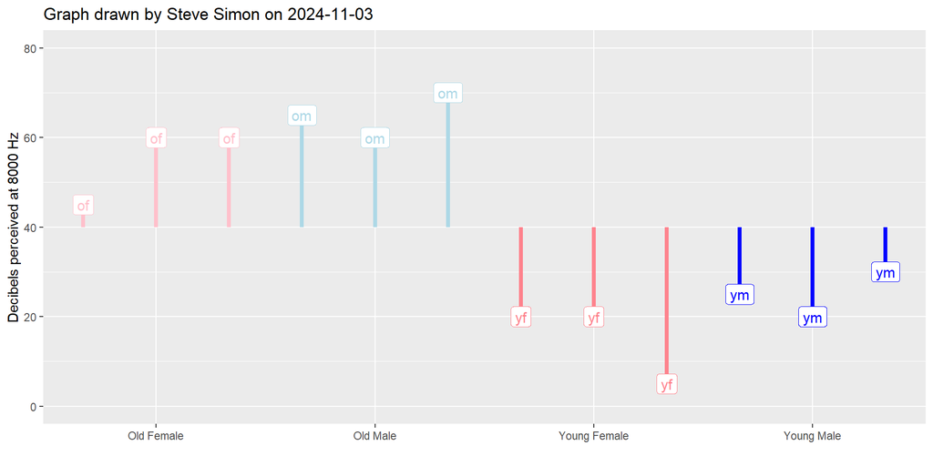

## SS(Age)

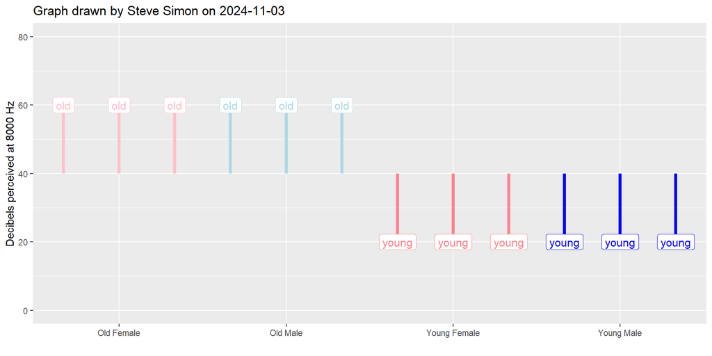

## SS(Gender)

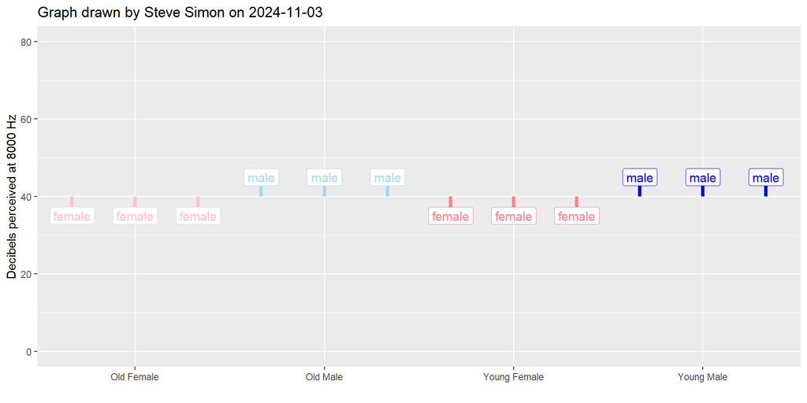

## Analysis of variance table

```
Analysis of Variance Table

Response: db
          Df Sum Sq Mean Sq F value    Pr(>F)
age        1   4800  4800.0  108.00 2.595e-06 ***
gender     1    300   300.0    6.75   0.02883 *
Residuals  9    400    44.4
---
Signif. codes:  0 '***' 0.001 '**' 0.01 '*' 0.05 '.' 0.1 ' ' 1
```

## Break #1

- What you have learned
  - Two factor analysis of variance
- What’s coming next
  - Relationship to linear regression

## Create indicator variables

```
# A tibble: 12 × 6
   age   gender code  i_young i_male    db
   <chr> <chr>  <chr>   <dbl>  <dbl> <dbl>
 1 old   female of          0      0    45
 2 old   female of          0      0    60
 3 old   female of          0      0    60
 4 old   male   om          0      1    65
 5 old   male   om          0      1    60
 6 old   male   om          0      1    70
 7 young female yf          1      0    20
 8 young female yf          1      0    20
 9 young female yf          1      0     5
10 young male   ym          1      1    25
11 young male   ym          1      1    20
12 young male   ym          1      1    30
```

## Two factor analysis of variance using aov

```r
m1 <- aov(db ~ age + gender, data=hearing)
anova(m1)
```

```
Analysis of Variance Table

Response: db
          Df Sum Sq Mean Sq F value    Pr(>F)
age        1   4800  4800.0  108.00 2.595e-06 ***
gender     1    300   300.0    6.75   0.02883 *
Residuals  9    400    44.4
---
Signif. codes:  0 '***' 0.001 '**' 0.01 '*' 0.05 '.' 0.1 ' ' 1
```

## Two factor analysis of variance using linear regression, 1

```r
m2 <- lm(db ~ age + gender, data=hearing)
anova(m2)
```

```
Analysis of Variance Table

Response: db
          Df Sum Sq Mean Sq F value    Pr(>F)
age        1   4800  4800.0  108.00 2.595e-06 ***
gender     1    300   300.0    6.75   0.02883 *
Residuals  9    400    44.4
---
Signif. codes:  0 '***' 0.001 '**' 0.01 '*' 0.05 '.' 0.1 ' ' 1
```

## Two factor analysis of variance using linear regression, 2

```r
tidy(m2)
```

```
# A tibble: 3 × 5
  term        estimate std.error statistic      p.value
  <chr>          <dbl>     <dbl>     <dbl>        <dbl>
1 (Intercept)     55        3.33     16.5  0.0000000492
2 ageyoung       -40        3.85    -10.4  0.00000260
3 gendermale      10.0      3.85      2.60 0.0288
```

## Break #2

- What you have learned
  - Relationship to linear regression
- What’s coming next
  - Checking assumptions

## Checking assumptions

- Normality (Non-normality)
- Homogeneity (Heterogeneity)
- Independence (Lack of independence)

## Use the boxplot to check assumptions

- Non-normality if boxplot shows skewness and/or outliers
- Heterogeneity if boxplot shows large change in variation
- Draw clustered boxplot to examine every combination of categories
  - Use a$\times$b boxplots
- Independence is checked qualitatively

## Alternatives if assumptions violated

- There is no analog to Kruskal-Wallis or Mann-Whitney-Wilcoxon
- Consider a log transformation
  - All values greater than 0
  - Groups with larger means have larger variation
  - Data is skewed right and outliers only on the high end

## Break #3

- What you have learned
  - Checking assumptions
- What’s coming next
  - R code for two factor analysis of variance

## Listing of full-moon-er-admissions.yaml, 1

```
---
data_dictionary: full-moon.txt

description: >
  The data give the admission rates to the
  emergency room of a Virginia mental health
  clinic before, during and after the 12
  full moons from August 1971 to July 1972.

additional_description:
  https://gksmyth.github.io/ozdasl/general/fullmoon.html
```

## Listing of full-moon-er-admissions.yaml, 2

```
source:
  - Blackman, S., and Catalina, D. (1973). The moon and the emergency room.
    Perceptual and Motor Skills 37, 624-626.
  - Ovlin, J. F. (1943). Moonlight and nervous disorders. American Journal of
    Psychiatry 99, 578-584.
  - Larsen, R.J., and Marx, M.L., (1986). An Introduction to Mathematical
    Statistics and Its Applications 2nd Edition. Prentice-Hall, Englewood
    Cliffs, New Jersey. Case Study 1.2.3.

copyright:
  unknown

format:
  tab-delimited
```

## Listing of full-moon-er-admissions.yaml, 3

```
varnames:
  first row of data

size:
  rows: 36
  columns: 3

vars:
  Month:
    label: Month of year
    scale: Aug, Sep, ..., Jul
```

## Listing of full-moon-er-admissions.yaml, 4

```
  Moon:
    label: time relative to full moon
    values:
      - Before
      - During
      - After

  Admission:
    label: Admission rate
    Unit: patients/day
```

## Listing of simon-5501-12-moon.qmd, 1

```
---
title: "Analysis of full-moon-er-admissions data"
format:
  html:
    embed-resources: true
---

This program reads data on admissions to an emergency room before, during, and
after a full moon. Find more information in the [data dictionary][dd].

[dd]: https://github.com/pmean/data/blob/master/files/full-moon-er-admissions.yaml

This code was written by Steve Simon on 2024-11-02 and is placed in the public
domain.
```

## Listing of simon-5501-12-moon.qmd, 2

````
## Load the tidyverse library

```{r setup}
#| message: false
#| warning: false
library(broom)
library(tidyverse)
```

For most of your programs, you should load the tidyverse library. The broom
library converts your output to a nicely arranged dataframe. The messages and
warnings are suppressed.
````

## Listing of simon-5501-12-moon.qmd, 3

````
## Read the data and view a brief summary

```{r read}
er <- read_tsv(
  "../data/full-moon-er-admissions.txt",
  col_types="ccn",
  col_names=TRUE)
names(er) <- tolower(names(er))
glimpse(er)
```

This is a tab delimited file. I changed all the variable names to all lowercase.
That's one less thing opportunity for inconsistency errors.
````

## Listing of simon-5501-12-moon.qmd, 4

````
## Reorder the category levels, 1

```{r reorder-moon}
er$moon1 <- factor(
  er$moon,
  levels=c(
    "Before",
    "During",
    "After"))
```

If you let R order the categories, it will do it alphabetically. The factor function will place them in a more logical order.
````

## Listing of simon-5501-12-moon.qmd, 5

````
## Reorder the category levels, 2

```{r reorder-month}
er$month1 <- factor(
  er$month,
  levels=c(
    "Aug", "Sep", "Oct",
    "Nov", "Dec", "Jan",
    "Feb", "Mar", "Apr",
    "May", "Jun", "Jul"))
```

Since the study started in August, it makes sense to order the months starting then. An alphabetical ordering (April first then August?) makes no sense here.
````

## Listing of simon-5501-12-moon.qmd, 6

````
## Draw boxplot of admission versus moon

```{r boxplots-admission-vs-moon}
#| fig.width: 6
#| fig.height: 2.0
er |>
  ggplot(aes(moon1, admission)) +
    geom_boxplot() +
    xlab("Moon phase") +
    ylab("ER admissions per day") +
    ggtitle("Graphs drawn by Steve Simon on 2024-11-02") +
    coord_flip()
```

Although there are a few outliers, I would not worry too much about the
normality assumption. It also looks like heterogeneity would not be too much of
a concern.
````

## Listing of simon-5501-12-moon.qmd, 7

[output not shown]

## Listing of simon-5501-12-moon.qmd, 8

````
## Calculate average ER admissions versus moon

```{r by-moon}
er |>
  group_by(moon1) |>
  summarize(
    admission_mn=mean(admission),
    admission_sd=sd(admission),
    n=n())
```

There is a slightly higher average admission rate and slightly more vaiation
during a full moon.
````

## Listing of simon-5501-12-moon.qmd, 9

````
## Calculate average ER admissions versus month

```{r by-month}
er |>
  group_by(month1) |>
  summarize(
    admission_mn=mean(admission),
    admission_sd=sd(admission),
    n=n())
```

Er admissions are trending upward over time and there is some evidence of
heterogeneity. Again, treat this with caution as there are only three
observations per month.
````

## Listing of simon-5501-12-moon.qmd, 10

````
## Analysis of variance

```{r anova}
m1 <- aov(admission ~ moon1 + month1, data=er)
anova(m1)
```

There is a borderline, but statistically significant difference in average
admission rates during different phases of the moon. There is a statistically
significant difference in average admission rates between some of the months.
````

## Listing of simon-5501-12-moon.qmd, 11

````
## Using lm, 1

```{r lm-1}
m2 <- lm(admission ~ moon1 + month1, data=er)
anova(m2)
```

The analysis of variance table using lm is the same as the analysis of variance
table using aov.
````

## Listing of simon-5501-12-moon.qmd, 12

````
## Using lm, 2

```{r lm-2}
tidy(m2)
```

The intercept represents the estimated average admission rate before a full moon
and during the month of August. The admission rate is 2.5 patients per day
higher during a full moon compared to a full moon. This is small but probably
still important. The difference in average admission rates is 0.54 patients per
day higher after a full moon compared to before a full moon. The remaining
estimates compare each month back to the first month (August).
````

## Listing of simon-5501-12-moon.qmd, 13

````
## Using lm, 3

```{r lm-3}
er |>
  group_by(moon1) |>
  summarize(admission_mn=mean(admission)) |>
  mutate(admission_before=first(admission_mn)) |>
  mutate(difference=admission_mn-admission_before)
```

This table shows how to calculate the regression coefficients associated with
phases of the moon. It is not really needed for the analysis, but helps
illustrate how these coefficients are computed.
````

## Listing of simon-5501-12-moon.qmd, 14

````
## Using lm, 4

```{r lm-4}
er |>
  group_by(month1) |>
  summarize(admission_mn=mean(admission)) |>
  mutate(admission_aug=first(admission_mn)) |>
  mutate(difference=admission_mn-admission_aug)
```

This table shows how to calculate the regression coefficients associated with
months of the year.
````

## Listing of simon-5501-12-moon.qmd, 15

````
## Save important files for later use

```{r save}
save(
  er,
  file="../data/full-moon-er-admissions.RData")
```
````

## Break #4

- What you have learned
  - R code for two factor analysis of variance
- What’s coming next
  - Interactions

## What is an interaction

- Impact of one variable is influenced by a second variable
- Example, influence of alcohol on sleeping pills
- Three types of interactions
  - Between two categorical predictors
  - Between a categorical and a continuous predictor
  - Between two continuous predictors
- Interactions greatly complicate interpretation

## Interaction plot

- X axis, first categorical variable
- Separate lines for second categorical variable
- Y axis, average outcome

## Hypothetical interaction plots, 1

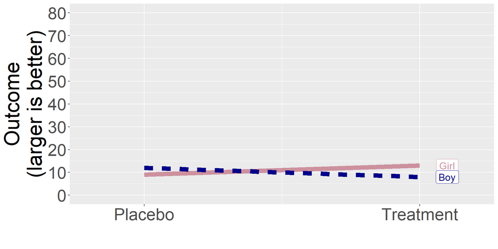

- No interaction
- Ineffective treatment
- Boys/girls similar

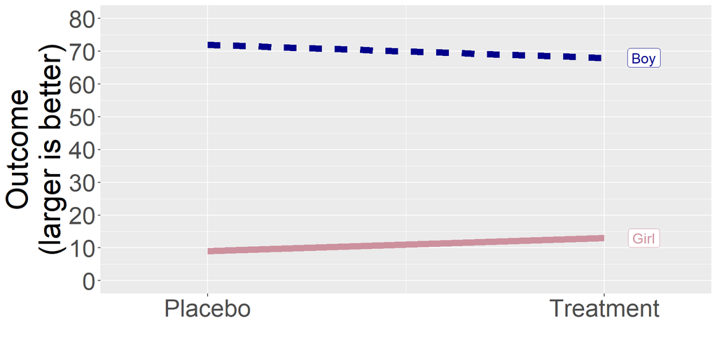

- No interaction
- Ineffective treatment
- Boys fare better than girls

## Hypothetical interaction plots, 2

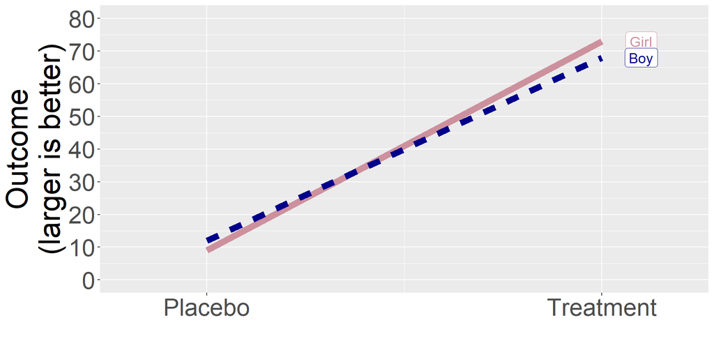

- No interaction
- Effective treatment
- Boys/girls similar

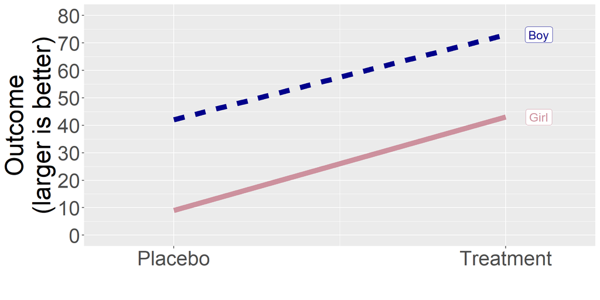

- No interaction
- Effective treatment
- Boys fare better than girls

## Hypothetical interaction plots, 3

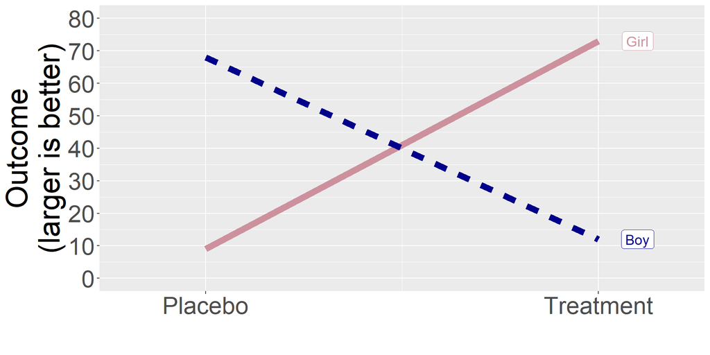

- Significant interaction
- Harmful treatment in boys
- Effective treatment in girls

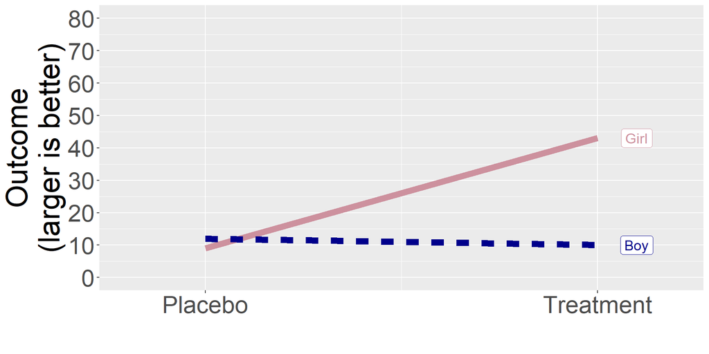

- Significant interaction
- Ineffective treatment in boys
- Effective treatment in girls

## Hypothetical interaction plots, 4

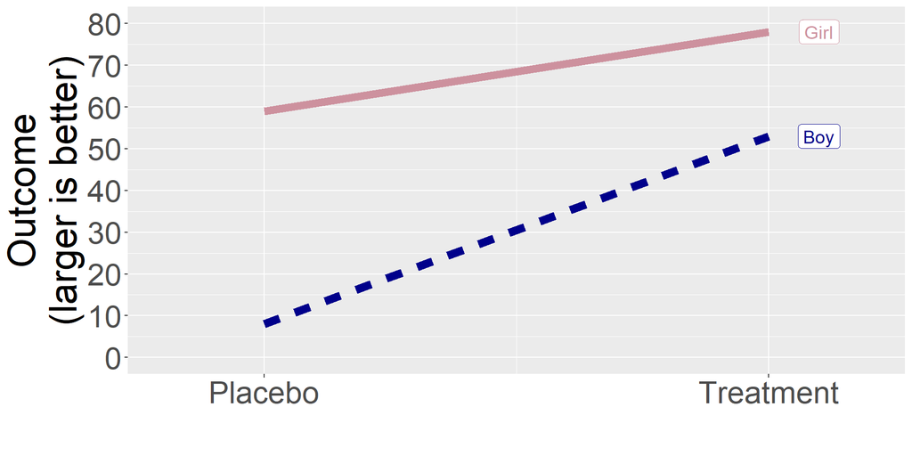

- Significant interaction
- Girls fare better overall
- Effective treatment
- Much more effective in boys

## Indicator variable for an interaction

```
# A tibble: 12 × 7
   age   gender code  i_young i_male i_m_by_y    db
   <chr> <chr>  <chr>   <dbl>  <dbl>    <dbl> <dbl>
 1 old   female of          0      0        0    45
 2 old   female of          0      0        0    60
 3 old   female of          0      0        0    60
 4 old   male   om          0      1        0    65
 5 old   male   om          0      1        0    60
 6 old   male   om          0      1        0    70
 7 young female yf          1      0        0    20
 8 young female yf          1      0        0    20
 9 young female yf          1      0        0     5
10 young male   ym          1      1        1    25
11 young male   ym          1      1        1    20
12 young male   ym          1      1        1    30
```

## Interpretation of intercept and slopes

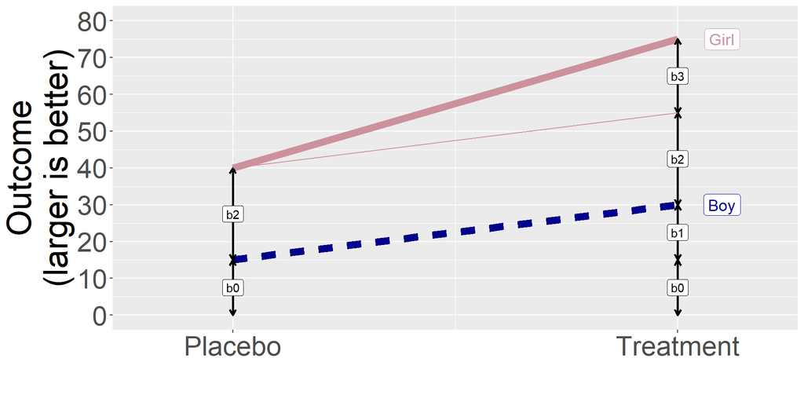

## When you can’t estimate an interaction

- Special case, n=1
  - Only one observation for categorical combination

## Example, full moon study, 1 of 2

```
# A tibble: 36 × 3
   month1 moon1      n
   <fct>  <fct>  <int>
 1 Aug    Before     1
 2 Aug    During     1
 3 Aug    After      1
 4 Sep    Before     1
 5 Sep    During     1
 6 Sep    After      1
 7 Oct    Before     1
 8 Oct    During     1
 9 Oct    After      1
10 Nov    Before     1
# ℹ 26 more rows
```

## Example, full moon study, 2 of 2

```r
m1 <- aov(admission ~ month*moon, data=er)
anova(m1)
```

```
Analysis of Variance Table

Response: admission
           Df Sum Sq Mean Sq F value Pr(>F)
month      11 455.58  41.417     NaN    NaN
moon        2  41.51  20.757     NaN    NaN
month:moon 22 127.82   5.810     NaN    NaN
Residuals   0   0.00     NaN
```

## Break #5

- What you have learned
  - Interactions
- What’s coming next
  - R code for interactions

## Listing of fruitfly.yaml, 1

```
---
data_dictionary: fruitfly.dat.txt

copyright: >
  This dataset is copyrighted by the authors of the Journal of Statistics
  Education article, but should be available for individual educational uses
  under the Fair Use provisions of copyright law.

description: >
  Does access to mating affect the lifespan of fruitflies? This data shows the
  longevity of male fruitflies in the presence or absence of female fruitflies
  to mate with. Male fruitflies were housed with 0, 1, or 8 females. In some
  groups, the females were pregnant and thus not available for mating. There are
  two covariates, length of the thorax and percentage of time sleeping, that
  might also influence longevity.
```

## Listing of fruitfly.yaml, 2

```
source:
  - Partridge, L., and Farquhar, M. (1981), "Sexual Activity and the Lifespan of
    Male Fruitflies," Nature, 294, 580-581.
  - James A. Hanley & Stanley H. Shapiro. Sexual Activity and the Lifespan of
    Male Fruitflies: A Dataset That Gets Attention. Journal of Statistics
    Education v.2, n.1 (1994)

additional_description:
  https://jse.amstat.org/datasets/fruitfly.txt

download_url:
  https://jse.amstat.org/datasets/fruitfly.dat.txt
```

## Listing of fruitfly.yaml, 3

```
format:
  fixed width

varnames:
  not included

missing_value_code:
  not needed

size:
  rows: 125
  columns: 6
```

## Listing of fruitfly.yaml, 4

```
vars:
  id:
    columns: 1-2

  partners:
    columns: 4
    label: Number of female partners
    values: 0, 1, or 8
```

## Listing of fruitfly.yaml, 5

```
  type:
    columns: 6
    label: Type of female fruitfly
    values:
      0: newly pregnant female
      1: virgin female
      9: not applicable (when partners=0)

  longevity:
    columns: 8-9
    label: Lifespan
    unit: days
    range: positive
```

## Listing of fruitfly.yaml, 6

```
  thorax:
    columns: 11-14
    label: Length of thorax
    unit: mm
    range: positive

  sleep:
    columns: 16-17
    label: Percentage of each day sleeping
    range: 0 to 100
---
```

## Listing of simon-5501-12-fruitfly.qmd, 1

```
---
title: "Analysis of fruitfly data"
format:
  html:
    embed-resources: true
---

This program reads data on fruit fly longevity. Find more information in the [data dictionary][dd].

[dd]: https://github.com/pmean/data/blob/master/files/fruitfly.yaml

This code was written by Steve Simon on 2024-10-29 and is placed in the public
domain.
```

## Listing of simon-5501-12-fruitfly.qmd, 2

````
## Load the tidyverse library

```{r setup}
#| message: false
#| warning: false
library(broom)
library(tidyverse)
```

#### Comments on the code

For most of your programs, you should load the tidyverse library. The broom
library converts your output to a nicely arranged dataframe. The messages and
warnings are suppressed.
````

## Listing of simon-5501-12-fruitfly.qmd, 3

````
## List the variable names

```{r variable-list}
vlist <- c(
  "id",
  "partners",
  "type",
  "longevity",
  "thorax",
  "sleep")
```
````

## Listing of simon-5501-12-fruitfly.qmd, 4

```
#### Comments on the code

When a dataset does not have variables on the first line, you need to specify
them in the code.
```

## Listing of simon-5501-12-fruitfly.qmd, 5

````
## Read the data and view a brief summary

```{r read}
fly <- read_fwf(
  "../data/fruitfly.txt",
  col_types="nnnnnn",
  fwf_widths(
    widths=c(2, 2, 2, 3, 5, 3),
    col_names=vlist))
glimpse(fly)
```
````

## Listing of simon-5501-12-fruitfly.qmd, 6

```
#### Comments on the code

The fruitfly dataset has a fixed width format (fwf). You need to specify the
columns that each variable uses.

Notice that the two categorical variables, partners and type, are actually
numbers rather than strings. To avoid having R treat these variables as if
they were continuous, use the factor function in some of the code below.
```

## Listing of simon-5501-12-fruitfly.qmd, 7

````
## Create a subset of fruitfly dataset

```{r subset}
fly |>
  filter(type != 9) -> fly_subset
```
````

## Listing of simon-5501-12-fruitfly.qmd, 8

```
#### Comments on the code

If you exclude the pure control group (No females), you can analyze the two
factors, partners and type individually. Partners has two category levels, 1 for
when one female was included in the cage and 8 for when eight females were
included in the cage. Type also has two category levels, 0 for pregnant female
fly/flies and 1 for virgin fly/flies. A male fly will not mate with a pregnant
females, so you can think of this as a second level of controls. The two factors
are crossed, meaning that every possible combination of partners and type has
outcomes measured.
```

## Listing of simon-5501-12-fruitfly.qmd, 9

````
## Draw boxplot of longevity by partners and type

```{r boxplots-partners-type}
#| fig.width: 6
#| fig.height: 2.5
fly_subset |>
  ggplot(aes(factor(partners), longevity, fill=factor(type))) +
    geom_boxplot() +
    xlab("Number of partners") +
    ylab("Lifespan in days") +
    ggtitle("Graphs drawn by Steve Simon on 2024-10-28") +
    labs(fill="Female fly type") +
    scale_fill_discrete(labels=c("Pregnant", "Virgin")) +
    coord_flip()
```
````

## Listing of simon-5501-12-fruitfly.qmd, 10

```
#### Interpretation of the output

The lifespans tend to be quite a bit shorter in cages with 8 virgin females.
There are no problems with the homogeneity and normality assumptions.
```

## Listing of simon-5501-12-fruitfly.qmd, 11

````
## Calculate average longevity by partners and type

```{r by-partners-and-type}
#| message: false
fly_subset |>
  group_by(type, partners) |>
  summarize(
    longevity_mn=mean(longevity),
    longevity_sd=sd(longevity),
    n=n()) -> fly_means
fly_means
```
````

## Listing of simon-5501-12-fruitfly.qmd, 12

```
#### Interpretation of the output

The means show the same pattern as noted above. The standard deviations are all
roughly the same.
```

## Listing of simon-5501-12-fruitfly.qmd, 13

````
## Draw line graph

```{r line-graph}
fly_means |>
  ggplot(aes(
    factor(partners),
    longevity_mn,
    group=factor(type),
    color=factor(type))) +
    geom_line(linewidth=2) +
    expand_limits(y=range(fly_subset$longevity)) +
  xlab("Number of partners") +
  ylab("Lifespan in days") +
  labs(color="Female fly type") +
  scale_color_discrete(labels=c("Pregnant", "Virgin"))
```
````

## Listing of simon-5501-12-fruitfly.qmd, 14

```
#### Interpretation of the output

This plot shows strong evidence of an interaction.

Male fruitflies do appear to have shorter average lifespans when sharing a cage
with virgin females compared to pregnant females, but this effect is far
stronger when the number of female fruitflies is eight rather than one.

The line for pregnant (sharing a cage with pregnant females) is close to flat,
indicating that there is little impact of the number of pregnant females on
average longevity.
```

## Listing of simon-5501-12-fruitfly.qmd, 15

````
## Analysis of variance including the interaction

```{r anova-with-interaction}
m1 <- aov(longevity ~ factor(partners)*factor(type), data=fly_subset)
anova(m1)
```

#### Interpretation of the output

There is a statistically significant interaction between the number of female
partners and the type of partners (pregnant or virgin). When you have an
interaction, you do not normally interpret the individual categorical
predictors.
````

## Listing of simon-5501-12-fruitfly.qmd, 16

````
## Using lm, 1

```{r lm-with-interactions-1}
m2 <- lm(longevity ~ factor(partners)*factor(type), data=fly_subset)
anova(m2)
```

#### Interpretation of the output

The analysis of variance table is identical when using lm instead of aov.
````

## Listing of simon-5501-12-fruitfly.qmd, 17

````
## Using lm, 2

```{r lm-with-interactions-2}
tidy(m2)
```

#### Interpretation of the output

The lifespan of fruitflies in cages with 8 virgin females is 17 days shorter
than what you would expect. If the effect of type and partners were independent,
you'd expect to see a 9.4 (= 8.0 + 1.4) day decline on average. The interaction
shows that this cage is actually 16.6 days worse than that on average.
````

## Listing of simon-5501-12-fruitfly.qmd, 18

````
## Using lm, 3

```{r add-coefficients}
b <- coef(m2)
fly_means |>
  mutate(b0=b[1]) |>
  mutate(b1=b[2]) |>
  mutate(b2=b[3]) |>
  mutate(b3=b[4]) |>
    select(-longevity_sd, -n) -> fly_coefficients
fly_coefficients[1, 5:7] <- 0
fly_coefficients[2, 6:7] <- 0
fly_coefficients[3, c(5,7)] <- 0
fly_coefficients
```
````

## Listing of simon-5501-12-fruitfly.qmd, 19

```
#### Comments on the code

The coef function takes the intercept and slopes from a linear regression model
and stores them in a vector. The mutate command adds the individual intercept
and slopes to separate columns. Finally, place zeros in places where the various
slopes are not needed.
```

## Listing of simon-5501-12-fruitfly.qmd, 20

```
#### Interpretation of the output

This table is not needed for the data analysis, but is included to illustrate
how the regression coefficients are computed in a two factor analysis of
variance with an interaction.

The intercept is the estimated average with both categories each to the "zero"
or reference level. In this case, the average lifespan of flies in a cage with
one pregnant female.

The first slope coefficient (b1) represents the estimated average difference in
lifespan between eight pregnant females and one pregnant females.

The second slope coefficient (b2) represents the estimated average difference in
lifespan between one pregnant females and one virgin female.

The third slope coefficient (b3) represents the interaction. It is a measure of
how much shorter the average lifespan is with eight virgin females above and
beyond the individual impact of eight versus one and virgin versus pregnant.
```

## Listing of simon-5501-12-fruitfly.qmd, 21

````
## Save important files for later use

```{r save}
save(
  fly,
  fly_subset,
  file="../data/fruitfly.RData")
```

#### Comments on the code

It is always good form to save the important pieces of your data analysis that
might be re-used sometime later.
````

## Break #6

- What you have learned
  - R code for interactions
- What’s coming next
  - Your homework

## Listing of simon-5501-12-directions.md, 1

```
---
title: "Directions for 5501-12 programming assignment"
---

This programming assignment was written by Steve Simon on 2024-10-08 and is placed in the public domain.
```

## Listing of simon-5501-12-directions.md, 2

```
## Program

-   Download the [program][tem]
    -   Store it in your src folder
-   Modify the file name
    -   Use your last name instead of "simon"
-   Modify the documentation header
    -   Add your name to the author field
    -   Optional: change the copyright statement

[tem]: https://github.com/pmean/classes/blob/master/general/simon-5501-12-fruitfly.md
```

## Listing of simon-5501-12-directions.md, 3

```
## Data

-   Download the [data][dat] file
    -   Store it in your data folder
-   Refer to the [data dictionary][dic], if needed.

[dat]: https://github.com/pmean/data/blob/main/files/fruitfly.txt
[dic]: https://github.com/pmean/data/blob/main/files/fruitfly.yaml
```

## Listing of simon-5501-12-directions.md, 4

```
## Question 1

Create a subset of the fruitfly data by removing the age where type equals 9.
Draw a clustered boxplot with sleep as the outcome and partners and type as the
categorical predictors. Interpret this graph. Is there evidence of
non-normality?

## Question 2

Calculate descriptive statistics for sleep (mean, standard deviation, and
sample size) by the combination of the two categorical predictors, partners and
type. Is there evidence of heterogeneity?
```

## Listing of simon-5501-12-directions.md, 5

```
## Question 3

Draw a line graph for the mean sleep levels compared by type and partners. Is
there evidence of an interaction?

## Question 4

Analyze the sleep variable using a two factor analysis of variance with an
interaction. Present and interpret the analysis of variance table.
```

## Listing of simon-5501-12-directions.md, 6

```
## Question 5

What factors might make you consider using a log transformation for the sleep
variable? Do not run such an analysis but tell us whether you think the data
would warrant such a transformation?
```

## Listing of simon-5501-12-directions.md, 7

```
## Your submission

-   Save the output in html format
-   Convert it to pdf format.
-   Make sure that the pdf file includes
    -   Your last name
    -   The number of this course
    -   The number of this module
-   Upload the file
-   Please note the [policy on late submissions and rework][sim3].

[sim3]: https://github.com/pmean/classes/blob/master/general/policy-on-extensions-and-rework.md
```

## Listing of simon-5501-12-directions.md, 8

```
## If it doesn't work

Please review the [suggestions if you encounter an error page][sim4].

[sim4]: https://github.com/pmean/classes/blob/master/general/suggestions-if-you-encounter-an-error.md
```

## Summary

- What you have learned
  - Two factor analysis of variance
  - Relationship to linear regression
  - Checking assumptions
  - R code for two factor analysis of variance
  - Interactions
  - R code for interactions
  - Your homework